# TED Talks Analysis

Tomer Eldor

1/26/2018

# What Makes A Ted Talk Popular?

Tomer Eldor January 26, 2018

*Have you ever wondered what makes some TED talks more popular than others?* Well, I’ve analyzed a dataset of 2550 ted talks to get some answers for this question. May aim was to explore which of my available variables of a given talk, such as the number of comments, number of languages translated, duration of the talk, number of tags, or day it was published online– are a strong predictor of its popularity, measured in number of views. *I don’t believe these analyses serve as a good causal inference*, since results wouldn’t be matched with these variables, their explanatory power isn’t rigorous enough. The available numerical parameters I had in hand are not sufficient for that kind of a conclusion; I couldn’t match the content that really matters to compare apples to apples, and even with controlling with multiple regression – not all things are equal (ceteris paribus assumption is still not met). However, I was able to get a decent predictor and understand which variables are most strongly associated with higher view counts. *What data did I have?* The dataset includes the name, title, description and URL of each of the 2550 talks, name and occupation of the main speaker, number of speakers, duration of the talk, the TED event and date it was filmed at, date it was published online, number of comments, languages translated and views. It also includes data points as the array of associated tags, ratings, and related talks, but as inside arrays and these need transformations before they can be used. For a full list, see comment.

## Loading dataset and libraries

```r
library(ggplot2) # Data visualisation
library(reshape2)
library(corrplot)
library(dplyr)
library(stringr) # String manipulation
library(anytime)
library(data.table)

ted = read.csv("./data/ted_main.csv",header=TRUE,stringsAsFactors = TRUE)
transcripts=read.csv("./data/transcripts.csv",header=TRUE,stringsAsFactors = FALSE)
```

# Summary Statistics

Here are some in a Summary Statistics - a few tables and appropriate graphs that describe the data.

## 1 - Histograms

Let’s examine the distributions of the key parameters that we’ll be using. To the right are histograms of most of our numerical variables. Below are some more detailed histograms, with a white line for the median and blue line for the mean. ¬¬

#### Histograms of all numerical variables

```r
print(summary(ted))
```

```
##     comments
##  Min.   :   2.0
##  1st Qu.:  63.0
##  Median : 118.0
##  Mean   : 191.6
##  3rd Qu.: 221.8
##  Max.   :6404.0
##
##                                                                                                                                                                                                                                                                                                          …
##  'I am a mathematician, and I would like to stand on your roof.' That is how Ron Eglash greeted many African families he met while researching the fractal patterns he'd noticed in villages across the continent.                                                                                       …
##  "A forest is much more than what you see," says ecologist Suzanne Simard. Her 30 years of research in Canadian forests have led to an astounding discovery -- trees talk, often and over vast distances. Learn more about the harmonious yet complicated social lives of trees and prepare to see the na…
##  "An advanced city is not one where even the poor use cars, but rather one where even the rich use public transport," argues Enrique Peñalosa. In this spirited talk, the mayor of Bogotá shares some of the tactics he used to change the transportation dynamic in the Colombian capital... and suggest…
##  "Anything that is worth pursuing is going to require us to suffer, just a little bit," says surf photographer Chris Burkard, as he explains his obsession with the coldest, choppiest, most isolated beaches on earth. With jawdropping photos and stories of places few humans have ever seen -- much l…
##  "Architecture is not about math or zoning -- it's about visceral emotions," says Marc Kushner. In a sweeping — often funny — talk, he zooms through the past thirty years of architecture to show how the public, once disconnected, have become an essential part of the design process. With the help …
##  "Babies and young children are like the R&D division of the human species," says psychologist Alison Gopnik. Her research explores the sophisticated intelligence-gathering and decision-making that babies are really doing when they play.                                                            …
##  (Other)                                                                                                                                                                                                                                                                                                 …
##     duration          event        film_date           languages
##  Min.   : 135.0   TED2014:  84   Min.   :7.465e+07   Min.   : 0.00
##  1st Qu.: 577.0   TED2009:  83   1st Qu.:1.257e+09   1st Qu.:23.00
##  Median : 848.0   TED2013:  77   Median :1.333e+09   Median :28.00
##  Mean   : 826.5   TED2016:  77   Mean   :1.322e+09   Mean   :27.33
##  3rd Qu.:1046.8   TED2015:  75   3rd Qu.:1.413e+09   3rd Qu.:33.00
##  Max.   :5256.0   TED2011:  70   Max.   :1.504e+09   Max.   :72.00
##                   (Other):2084
##         main_speaker
##  Hans Rosling :   9
##  Juan Enriquez:   7
##  Marco Tempest:   6
##  Rives        :   6
##  Bill Gates   :   5
##  Clay Shirky  :   5
##  (Other)      :2512
##                                                                          name
##  Aakash Odedra: A dance in a hurricane of paper, wind and light            :   1
##  Aala El-Khani: What it's like to be a parent in a war zone                :   1
##  Aaron Huey: America's native prisoners of war                             :   1
##  Aaron Koblin: Visualizing ourselves ... with crowd-sourced data           :   1
##  Aaron O'Connell: Making sense of a visible quantum object                 :   1
##  Abe Davis: New video technology that reveals an object's hidden properties:   1
##  (Other)                                                                   :2544
```

[output cut: 49 more lines]

```
##  https://www.ted.com/talks/9_11_healing_the_mothers_who_found_forgiveness_friendship\n:   1
##  https://www.ted.com/talks/a_choir_as_big_as_the_internet\n                           :   1
##  https://www.ted.com/talks/a_j_jacobs_year_of_living_biblically\n                     :   1
##  https://www.ted.com/talks/a_robot_that_flies_like_a_bird\n                           :   1
##  https://www.ted.com/talks/a_ted_speaker_s_worst_nightmare\n                          :   1
##  https://www.ted.com/talks/a_whistleblower_you_haven_t_heard\n                        :   1
##  (Other)                                                                              :2544
##      views
##  Min.   :   50443
##  1st Qu.:  755793
##  Median : 1124524
##  Mean   : 1698297
##  3rd Qu.: 1700760
##  Max.   :47227110
##
```

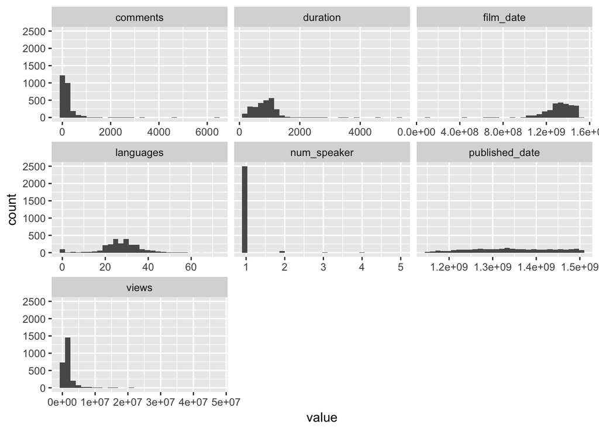

```r
melted_ted <- melt(ted)
ggplot(data = melted_ted, mapping = aes(x = value)) +
    geom_histogram(bins = 30) +  # 30 bins represented the distribution well from trying values between 10 and 100, and is also the minimum for normal distribution so it can show well if we'd have a normal distribution.
  # tried to force non-scientific notation, but the numbers are too long to represent, so I removed it.
   #scale_x_continuous(labels = function(x) format(x, scientific = FALSE)) +
    facet_wrap(~variable, scales = 'free_x')
```

#### Converting Dates into variables

```r
ted$date_pub = anydate(ted$published_date)
ted$month = month(ted$date_pub)
ted$year = year(ted$date_pub)
ted$day = weekdays(ted$date_pub,abbreviate = TRUE)
head(ted,3)
```

```
##   comments
## 1     4553
## 2      265
## 3      124
##                                                                                                                                                                                                                                 description
## 1                                                                                     Sir Ken Robinson makes an entertaining and profoundly moving case for creating an education system that nurtures (rather than undermines) creativity.
## 2 With the same humor and humanity he exuded in "An Inconvenient Truth," Al Gore spells out 15 ways that individuals can address climate change immediately, from buying a hybrid to inventing a new, hotter brand name for global warming.
## 3                                New York Times columnist David Pogue takes aim at technology’s worst interface-design offenders, and provides encouraging examples of products that get it right. To funny things up, he bursts into song.
##   duration   event  film_date languages main_speaker
## 1     1164 TED2006 1140825600        60 Ken Robinson
## 2      977 TED2006 1140825600        43      Al Gore
## 3     1286 TED2006 1140739200        26  David Pogue
##                                        name num_speaker published_date
## 1 Ken Robinson: Do schools kill creativity?           1     1151367060
## 2      Al Gore: Averting the climate crisis           1     1151367060
```

[output cut: 29 more lines]

#### Converting tags variable to number of tags

```r
typeof(ted$tags[1])
```

```
## [1] "integer"
```

```r
split(as.character(ted$tags[1]),", ")
```

```
## $`, `
## [1] "['children', 'creativity', 'culture', 'dance', 'education', 'parenting', 'teaching']"
```

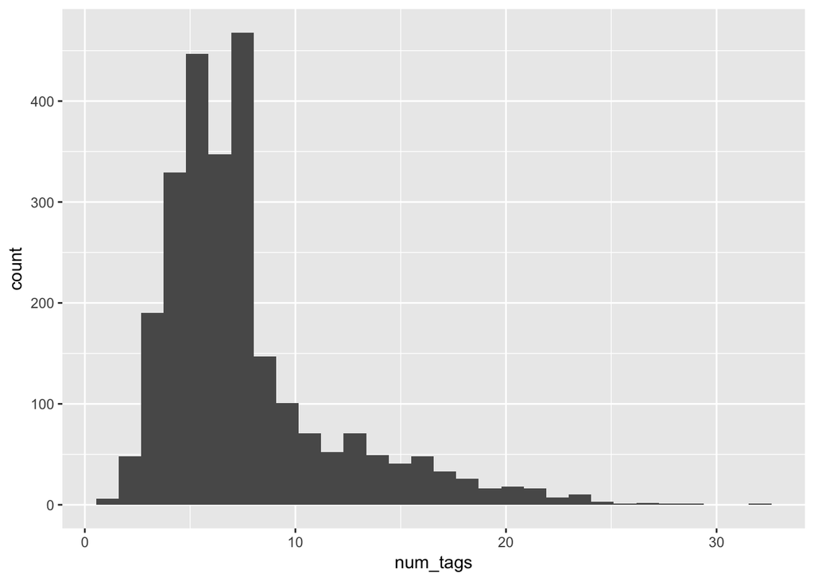

```r
#splitting did not work well. I'll just use the count of how many tags for now
library(stringr)
ted$num_tags <- str_count(ted$tags, ",") +1 #counting how many tags by counting the number of commas and adding one. I verified it worked well.
# quick histogram of the number of tags
qplot(x=num_tags,data=ted)
```

Most frequent numbers of tages are around 4-7 tags. Since the distribution is skewed, regression might work best over a polynomial or factored (cateogircal) representation of this. I’ll inspect this later

### Distribution of the duration of a talk

```r
median_duration <- median(ted$duration)
cat("Median number of duration: ", median(ted$duration))
```

```
## Median number of duration:  848
```

```r
print("")
```

```
## [1] ""
```

```r
cat("Mean number of duration: ", mean(ted$duration))
```

```
## Mean number of duration:  826.5102
```

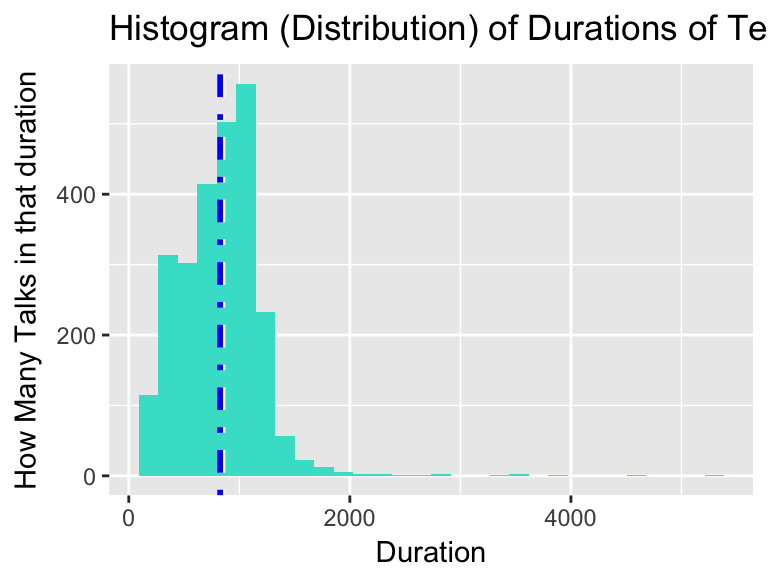

```r
# simple r histogram:
# hist(ted$duration)
# a nicer histogram using ggplot, also adding median number of duration line
duration_hist = ggplot(ted,aes(duration,..count..)) +
  geom_histogram(fill="turquoise") +
  labs(x="Duration",y="How Many Talks in that duration",title="Histogram (Distribution) of Durations of TedTalks") +
  #scale_x_continuous(limits=c(0,1500),breaks=seq(0,1500,150)) +
  geom_vline(aes(xintercept = median(ted$duration)),linetype=4,size=1,color="white") +
  geom_vline(aes(xintercept = mean(ted$duration)),linetype=4,size=1,color="blue")
duration_hist
```

### Distriubtion of number of views

```r
### Distribution of the number of views (in the discussion) per talk
median_views <- median(ted$views)
cat("Median number of views: ", median(ted$views))
```

```
## Median number of views:  1124524
```

```r
cat("Mean number of views: ", mean(ted$views))
```

```
## Mean number of views:  1698297
```

[figure not shown]

```r
# simple r histogram:
hist(ted$views)
```

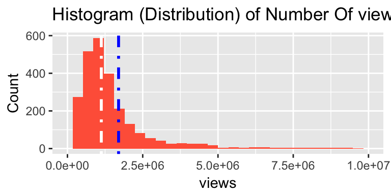

```r
# a nicer histogram using ggplot, also adding median number of views line
views_hist = ggplot(ted,aes(views,..count..)) +
  geom_histogram(fill="tomato") +
  labs(x="views",y="Count",title="Histogram (Distribution) of Number Of views", scientific = FALSE) +
  scale_x_continuous(limits=c(0,10000000)) + #,breaks=seq(0,10000000,10000),labels = function(x) format(x, scientific = FALSE) ) +
  #theme(axis.text.x = element_text(angle = 90, hjust = 1)) +
  geom_vline(aes(xintercept = median(ted$views)),linetype=4,size=1,color="white") +
  geom_vline(aes(xintercept = mean(ted$views)),linetype=4,size=1,color="blue")

views_hist
```

### Distribution of the number of comments (in the discussion) per talk

```r
median_comments <- median(ted$comments)
cat("Median number of comments: ", median(ted$comments))
```

```
## Median number of comments:  118
```

```r
cat("Mean number of comments: ", mean(ted$comments))
```

```
## Mean number of comments:  191.5624
```

[figure not shown]

```r
# simple r histogram:
hist(ted$comments)
```

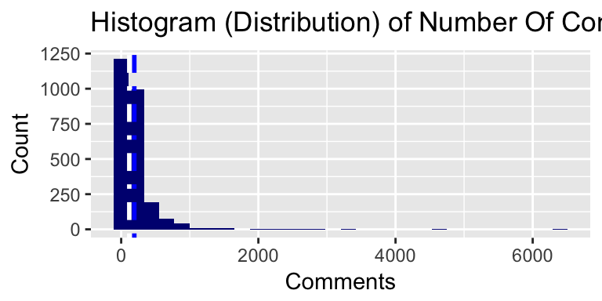

```r
# a nicer histogram using ggplot, also adding median number of comments line
comments_hist = ggplot(ted,aes(comments,..count..)) +
  geom_histogram(fill="navy") +
  labs(x="Comments",y="Count",title="Histogram (Distribution) of Number Of Comments") +
  #scale_x_continuous(limits=c(0,1500),breaks=seq(0,1500,150)) +
  geom_vline(aes(xintercept = median(ted$comments)),linetype=4,size=1,color="white") +
  geom_vline(aes(xintercept = mean(ted$comments)),linetype=4,size=1,color="blue")

comments_hist
```

Let’s explore occupations. Let’s first see 10 most popular occuptions

```r
occupation_df <- data.frame(table(ted$speaker_occupation))
colnames(occupation_df) <- c("occupation", "appearances")
occupation_df <- occupation_df %>% arrange(desc(appearances))
head(occupation_df, 10)
```

```
##      occupation appearances
## 1        Writer          45
## 2        Artist          34
## 3      Designer          34
## 4    Journalist          33
## 5  Entrepreneur          31
## 6     Architect          30
## 7      Inventor          27
## 8  Psychologist          26
## 9  Photographer          25
## 10    Filmmaker          21
```

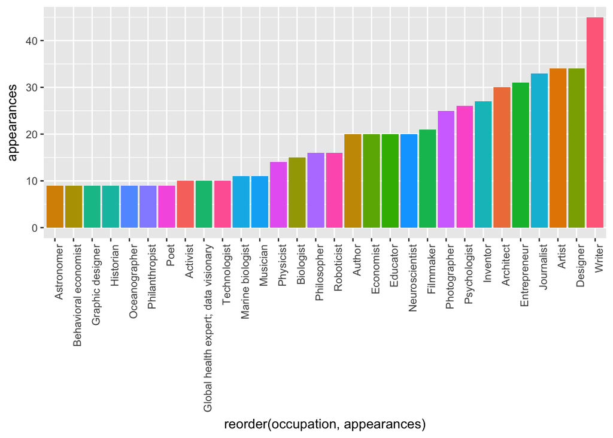

```r
ggplot(head(occupation_df,30),
       aes(x=reorder(occupation, appearances),
           y=appearances, fill=occupation)) +
  theme(axis.text.x = element_text(angle = 90, hjust = 1)) +
  geom_bar(stat="identity") +
  guides(fill=FALSE)
```

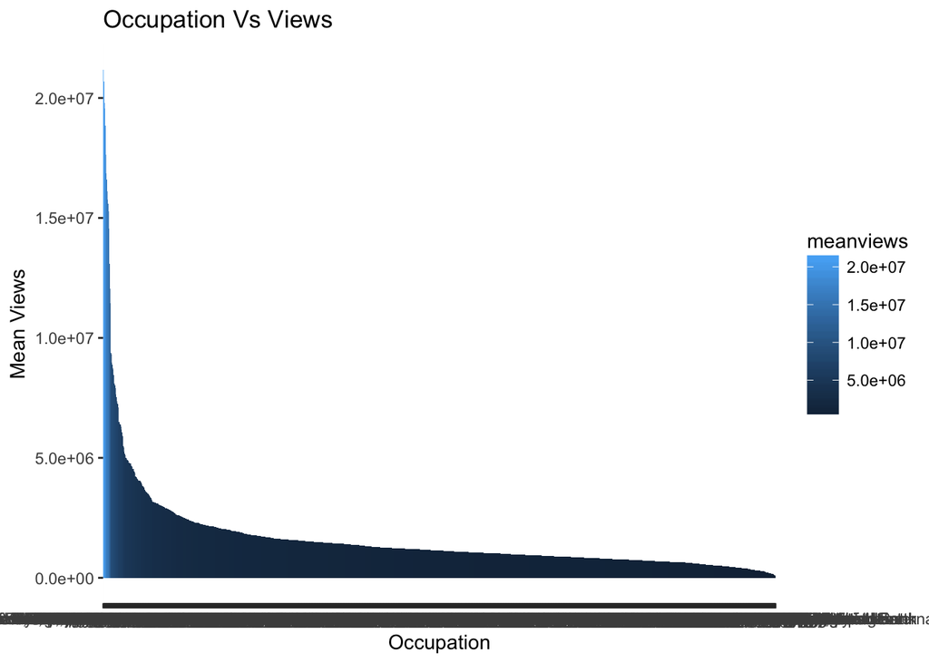

```r
ted_occupation_summary = ted %>% group_by(speaker_occupation) %>% summarise(meanviews=mean(views)) %>% arrange(desc(meanviews))


ggplot(ted_occupation_summary,
  aes(factor(speaker_occupation,levels=speaker_occupation), meanviews,fill=meanviews))+
  geom_bar(stat="identity")+
  labs(x="Occupation" ,y="Mean Views",title="Occupation Vs Views")
```

```r
  #scale_fill_brewer(name="Occupation",palette = "Set2")#+
  #scale_y_discrete(labels=scales::comma)
```

Days of week Published vs Views

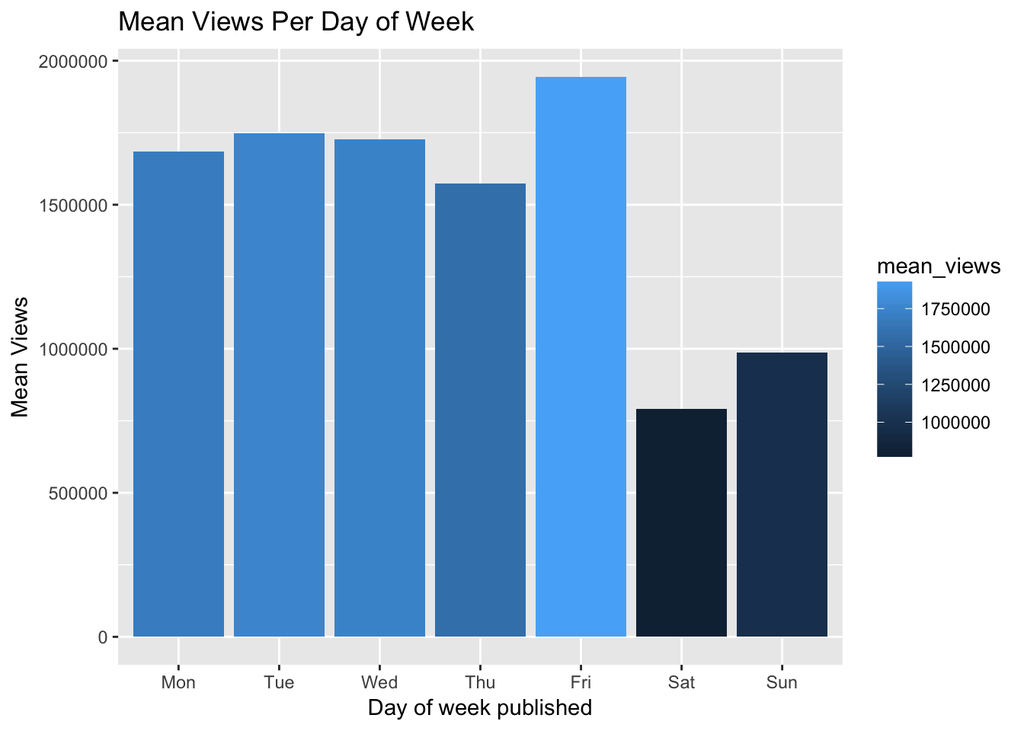

```r
# group by day and count total views, using dpyler
ted_by_day = ted %>% group_by(day) %>% summarise(mean_views=mean(views)) %>% arrange(desc(mean_views))
ted_by_day$day <- factor(ted_by_day$day, levels = c("Mon","Tue","Wed","Thu","Fri","Sat","Sun"))

ggplot(data = ted_by_day, aes(x = factor(day), y = mean_views, fill = mean_views)) +
  geom_bar(stat="identity") +
  labs(x="Day of week published",y="Mean Views",title="Mean Views Per Day of Week")
```

So day of week does seem to have some association with average (mean) views! Ted Talks published on weekends seem to have much less views, with Saturday being the lowest, and Friday is the most popular day for ted talks published day. Since it seems that the major effect is “Weekend or not”, I’m creating a binary dummy variable for is it weekend or not to regress upon later.

```r
# creating a is_weekend variable
library(chron)
ted$weekend <- as.numeric(is.weekend(ted$date_pub))
```

## 2 - Correlations between parameteres

First is a correlation (pairs) scatterplot matrix between each pair of numerical variables; Below is a correlation matrix with colors representing the intensity of the correlation from 0 (white) to dark blue (+1) or dark striped red (strong negative correlation, -1), and with asterisks (***) signifying significance by p-values.

## Correlations

```r
colnames(ted)
```

```
##  [1] "comments"           "description"        "duration"
##  [4] "event"              "film_date"          "languages"
##  [7] "main_speaker"       "name"               "num_speaker"
## [10] "published_date"     "ratings"            "related_talks"
## [13] "speaker_occupation" "tags"               "title"
## [16] "url"                "views"              "date_pub"
## [19] "month"              "year"               "day"
## [22] "num_tags"           "weekend"
```

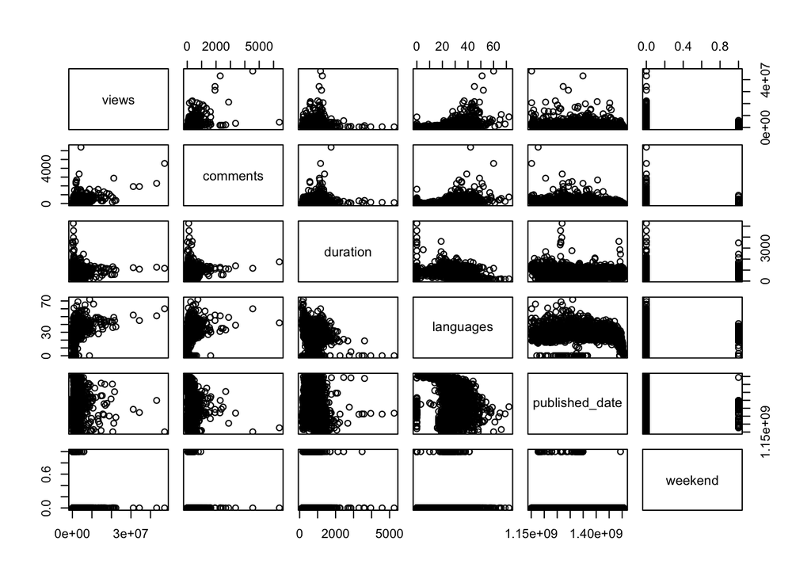

```r
col_numeric =  c(17,1,3,6,10,23) # comments,duration,film_date,languages,views)
ted_numeric = ted[,col_numeric]
pairs(ted_numeric)
```

We see some correlations there but not many clear ones; between views, comments and languages. No clear corerlation between views and duration or published date.

```r
cor_matrix <- cor(ted_numeric)
res <- cor.mtest(ted_numeric, conf.level = .95)
res
```

```
## $p
##               [,1]          [,2]         [,3]         [,4]         [,5]
## [1,]  0.000000e+00 1.803322e-185 1.383469e-02 3.140578e-87 3.657160e-01
## [2,] 1.803322e-185  0.000000e+00 9.558285e-13 3.950633e-61 2.869772e-21
## [3,]  1.383469e-02  9.558285e-13 0.000000e+00 1.279484e-52 2.819913e-17
## [4,]  3.140578e-87  3.950633e-61 1.279484e-52 0.000000e+00 2.370426e-18
## [5,]  3.657160e-01  2.869772e-21 2.819913e-17 2.370426e-18 0.000000e+00
## [6,]  5.820279e-04  6.932328e-01 1.003110e-01 8.566019e-35 2.459542e-05
##              [,6]
## [1,] 5.820279e-04
## [2,] 6.932328e-01
## [3,] 1.003110e-01
## [4,] 8.566019e-35
## [5,] 2.459542e-05
## [6,] 0.000000e+00
```

[output cut: 25 more lines]

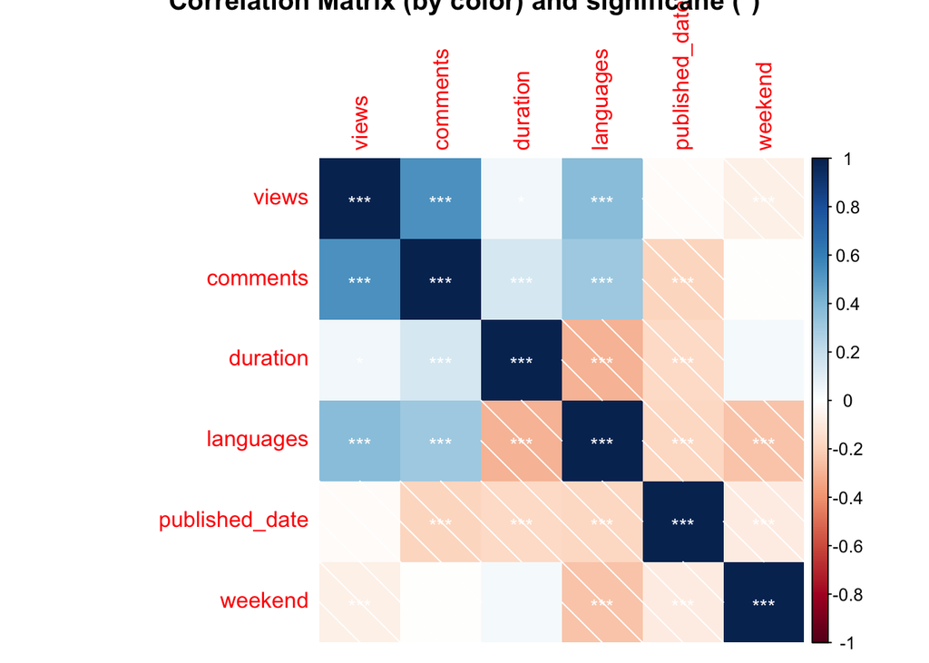

```r
corrplot::corrplot(cor_matrix,method="shade",bg="white",title="Correlation Matrix (by color) and significane (*)",
                   p.mat = res$p,  sig.level = c(.001, .01, .05), pch.cex = .9, insig = "label_sig", pch.col = "white")
```

These correlation plots and correlation matrix show us the following conclusions: * There is a relatively higher positive correlation between number of comments and views, which makes sense (more audience, more comments); * Some positive correlation between number of languages of translation and number of views (0.38) and number of comments (0.32) * Small negative correlation between duration and number of languages; the shorter the talk, the more tranlsated languages there are, probably because it is easier to translate.

Most of the parameters don’t have strong correlations. Naturally, there was a very high correlation between published data and filmed date. Filmed date seemed to be less associated with views numerically and logically – since the audience is more affected by the date a ted talk is released than whether it was recorded a month ago or a year ago. There is a relatively higher positive correlation between number of comments and views, which makes sense (more audience, more comments); Some positive correlation between number of languages of translation and number of views (0.38) and number of comments (0.32) Small negative correlation between duration and number of languages; the shorter the talk, the more translated languages there are, probably because it is easier to translate.

## 3 - Correlation Of Paramteres with Numbers of Views

How do these variables correlate with views? Is it a linear relationship, nonlinear, or non? This is important to understand to know how to insert them into the regression if at all.

Here I’ll start inspecting what are the correlations between vriables and the dependent variable, and what kind of relationship would suit to include in the regression between them (linear? polynomial? factor? none?)

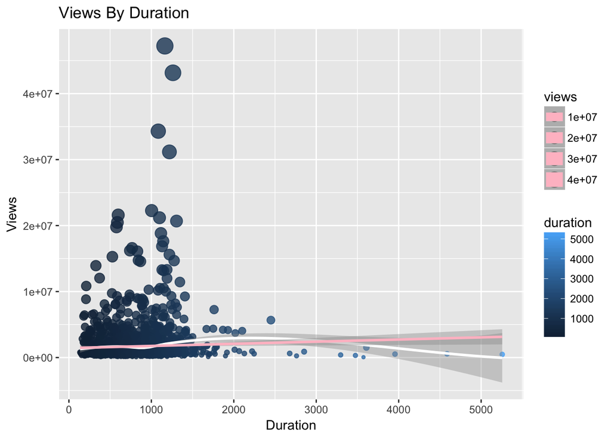

```r
# Views By Duraion
ggplot(ted, aes(duration, views, size = views, col = duration)) +
  geom_point(alpha=0.8) +
  geom_smooth(method = loess, colour="White") +
  geom_smooth(method = lm, colour="Pink") +
  labs(x="Duration",y="Views",title="Views By Duration") #+
```

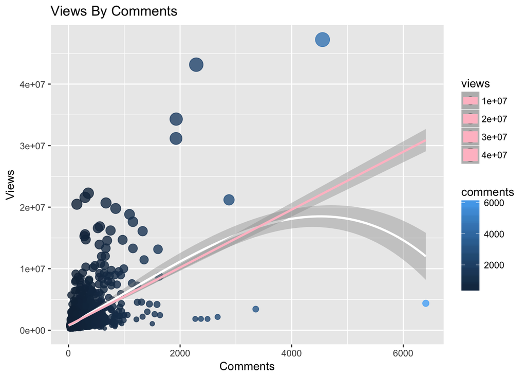

```r
# Views By Comments
ggplot(ted, aes(comments, views, size = views, col = comments)) +
  geom_point(alpha=0.8) +
  geom_smooth(method = loess, colour="White") +
  geom_smooth(method = lm, colour="Pink") +
  labs(x="Comments",y="Views",title="Views By Comments") #+
```

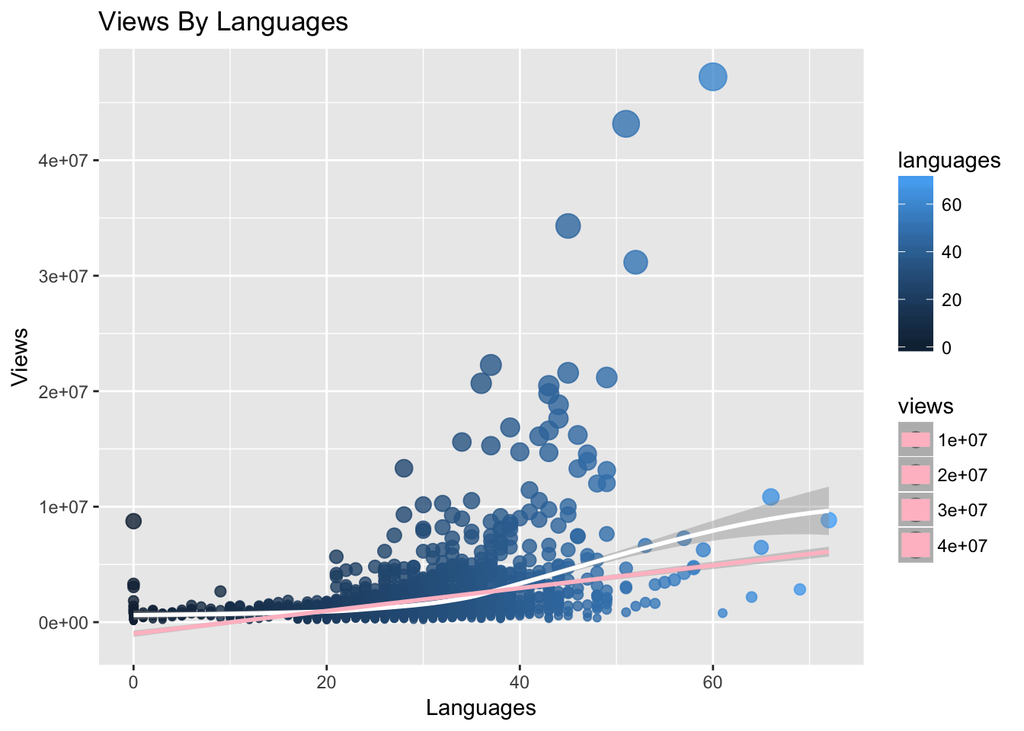

```r
# Views By Languages
ggplot(ted, aes(languages, views, size = views, col = languages)) +
  geom_point(alpha=0.8) +
  geom_smooth(method = loess, colour="White") +
  geom_smooth(method = lm, colour="Pink") +
  labs(x="Languages",y="Views",title="Views By Languages")
```

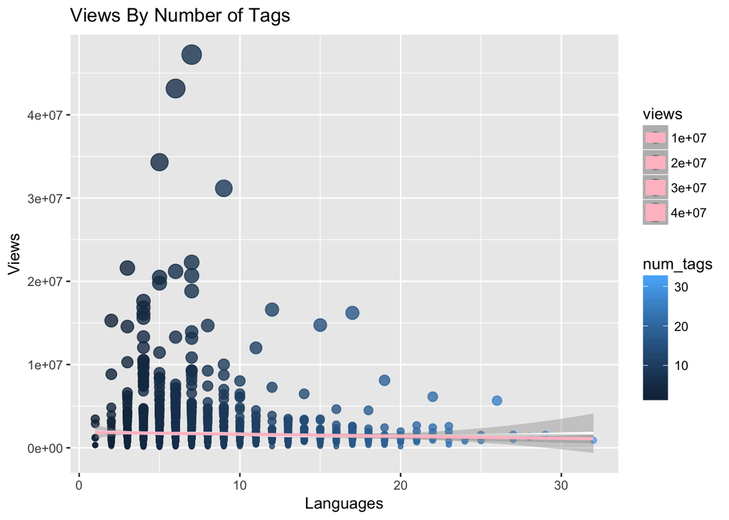

```r
# Views By Number of Tags
ggplot(ted, aes(num_tags, views, size = views, col = num_tags)) +
  geom_point(alpha=0.8) +
  geom_smooth(method = loess, colour="White") +
  geom_smooth(method = lm, colour="Pink") +
  labs(x="Languages",y="Views",title="Views By Number of Tags")
```

It seems that non of these loose much information by a linear regression versus a LOESS regression, which is arbitrarily flexible and would reveal a clear non-linear shape. while some of them do have nonlinear shapes - from a closer look, it is only in the tail where data is scarce and it is biasd by the few datapoints there and some outliers (as in the Comments correlation). Therefore, inputting the regressor as a linear fit might be sufficiently explanatory.

Surprisingly, duration had almost no consistent correlation with number of views; except for the fact that most popular talks were closer to 8-20 minutes. Number of comments is, obviously, very well correlated with number of views and so does number of languages – they all come from having many viewers. Thus, it is not “fair” to predict views based on these factors, and in the real world, we couldn’t use these parameters to predict, since they are not causes for more views, but they are also a result of many views, and a cause in a reinforcing feedback loop: the more comments, the more engaged the community is around the talk and likelier to spread; the more languages, the more viewers can watch; and the more viewers, the more audience there is to comment and translate. The rest had a small linear effect, where that didn’t deviate much, though small.

#### Regression Models

I inspected how does each of hte relevant variables explain the view count individually, and how does then adding (the relevant) one to a multiple regression improves its performance.

```r
fit1 <- lm(views  ~ comments, data = ted)
summary(fit1)
```

```
##
## Call:
## lm(formula = views ~ comments, data = ted)
##
## Residuals:
##       Min        1Q    Median        3Q       Max
## -26514433   -667711   -254429    229873  31596994
##
## Coefficients:
##             Estimate Std. Error t value Pr(>|t|)
## (Intercept) 798186.6    50681.6   15.75   <2e-16 ***
## comments      4698.8      148.6   31.63   <2e-16 ***
## ---
## Signif. codes:  0 '***' 0.001 '**' 0.01 '*' 0.05 '.' 0.1 ' ' 1
##
## Residual standard error: 2118000 on 2548 degrees of freedom
## Multiple R-squared:  0.2819, Adjusted R-squared:  0.2816
## F-statistic:  1000 on 1 and 2548 DF,  p-value: < 2.2e-16
```

```r
fit2 <- lm(views  ~ languages, data = ted)
summary(fit2)
```

```
##
## Call:
## lm(formula = views ~ languages, data = ted)
##
## Residuals:
##      Min       1Q   Median       3Q      Max
## -4235090  -887422  -418475   287948 42305382
##
## Coefficients:
##             Estimate Std. Error t value Pr(>|t|)
## (Intercept)  -997579     138744   -7.19 8.47e-13 ***
## languages      98655       4792   20.59  < 2e-16 ***
## ---
## Signif. codes:  0 '***' 0.001 '**' 0.01 '*' 0.05 '.' 0.1 ' ' 1
##
## Residual standard error: 2314000 on 2548 degrees of freedom
## Multiple R-squared:  0.1426, Adjusted R-squared:  0.1423
## F-statistic: 423.8 on 1 and 2548 DF,  p-value: < 2.2e-16
```

```r
fit3 <- lm(views  ~ duration, data = ted)
summary(fit3)
```

```
##
## Call:
## lm(formula = views ~ duration, data = ted)
##
## Residuals:
##      Min       1Q   Median       3Q      Max
## -2667314  -932675  -554748    28483 45418926
##
## Coefficients:
##              Estimate Std. Error t value Pr(>|t|)
## (Intercept) 1429186.7   119912.2  11.919   <2e-16 ***
## duration        325.6      132.2   2.463   0.0138 *
## ---
## Signif. codes:  0 '***' 0.001 '**' 0.01 '*' 0.05 '.' 0.1 ' ' 1
##
## Residual standard error: 2496000 on 2548 degrees of freedom
## Multiple R-squared:  0.002376,   Adjusted R-squared:  0.001984
## F-statistic: 6.068 on 1 and 2548 DF,  p-value: 0.01383
```

```r
# Adding date related information using just a weekday binary
fit4 <- lm(views ~ ted$weekend, data=ted)
summary(fit4)
```

```
##
## Call:
## lm(formula = views ~ ted$weekend, data = ted)
##
## Residuals:
##      Min       1Q   Median       3Q      Max
## -1683960  -934543  -576696     5606 45492707
##
## Coefficients:
##             Estimate Std. Error t value Pr(>|t|)
## (Intercept)  1734403      50473  34.363  < 2e-16 ***
## ted$weekend  -836986     243014  -3.444 0.000582 ***
## ---
## Signif. codes:  0 '***' 0.001 '**' 0.01 '*' 0.05 '.' 0.1 ' ' 1
##
## Residual standard error: 2493000 on 2548 degrees of freedom
## Multiple R-squared:  0.004634,   Adjusted R-squared:  0.004243
## F-statistic: 11.86 on 1 and 2548 DF,  p-value: 0.000582
```

```r
# weekend was significant, with a large slope (-836986) but didn't explain data well alone.

fit5 <- lm(views  ~ num_tags, data = ted)
summary(fit5)
```

```
##
## Call:
## lm(formula = views ~ num_tags, data = ted)
##
## Residuals:
##      Min       1Q   Median       3Q      Max
## -1710677  -959176  -550980    24372 45516020
##
## Coefficients:
##             Estimate Std. Error t value Pr(>|t|)
## (Intercept)  1886196      99359   18.98   <2e-16 ***
## num_tags      -25015      11474   -2.18   0.0293 *
## ---
## Signif. codes:  0 '***' 0.001 '**' 0.01 '*' 0.05 '.' 0.1 ' ' 1
##
## Residual standard error: 2497000 on 2548 degrees of freedom
## Multiple R-squared:  0.001862,   Adjusted R-squared:  0.00147
## F-statistic: 4.753 on 1 and 2548 DF,  p-value: 0.02933
```

The comments and languages where significantly and (relatively highly) positively correlated with views. Day of week seeemed to have some correlation - weekend days reduced the views. I therefore just regress on a binary variable weekend or weekday, since the nunmber of the day of the week didn’t have a clear correlation.

### Excluded Variables

```r
# Excluded anlaysis

summary(lm(views  ~ event, data = ted))
```

```
##
## Call:
## lm(formula = views ~ event, data = ted)
##
## Residuals:
##       Min        1Q    Median        3Q       Max
## -15027899   -850943   -300075     86910  43952765
##
## Coefficients:
##                                           Estimate Std. Error t value
## (Intercept)                                 149818    2447735   0.061
## eventArbejdsglaede Live                     821776    3461619   0.237
## eventBBC TV                                 372156    3461619   0.108
## eventBowery Poetry Club                     526923    3461619   0.152
## eventBusiness Innovation Factory            154268    2826400   0.055
## eventCarnegie Mellon University             414963    3461619   0.120
## eventChautauqua Institution                 111051    2826400   0.039
## eventDICE Summit 2010                       299343    3461619   0.086
## eventDLD 2007                               613997    3461619   0.177
## eventEG 2007                                887449    2540134   0.349
## eventEG 2008                               1898441    2596215   0.731
## eventElizabeth G. Anderson School           876771    3461619   0.253
## eventEric Whitacre's Virtual Choir          249462    3461619   0.072
## eventFort Worth City Council                128854    3461619   0.037
## eventFull Spectrum Auditions               1022540    2826400   0.362
## eventGel Conference                         506574    2997850   0.169
## eventGlobal Witness HQ                      865865    3461619   0.250
## eventHandheld Learning                      101495    3461619   0.029
## eventHarvard University                    1256333    3461619   0.363
## eventINK Conference                        1493142    2643856   0.565
## eventJustice with Michael Sandel            243641    3461619   0.070
## eventLIFT 2007                             1337035    3461619   0.386
## eventMichael Howard Studios                  27177    3461619   0.008
## eventMission Blue II                       1179654    2596215   0.454
## eventMission Blue Voyage                    385465    2514808   0.153
## eventNew York State Senate                  142577    3461619   0.041
## eventNextGen:Charity                        143808    3461619   0.042
## eventPrinceton University                   509846    3461619   0.147
## eventRoyal Institution                      168605    3461619   0.049
## eventRSA Animate                            865947    2826400   0.306
```

[output cut: 672 more lines]

```
## eventTEDYouth 2012                         0.97116
## eventTEDYouth 2013                         0.77365
## eventTEDYouth 2014                         0.68645
## eventTEDYouth 2015                         0.54547
## eventThe Do Lectures                       0.99136
## eventToronto Youth Corps                   0.79962
## eventUniversity of California              0.97020
## eventWeb 2.0 Expo 2008                     0.86060
## eventWorld Science Festival                0.36255
## ---
## Signif. codes:  0 '***' 0.001 '**' 0.01 '*' 0.05 '.' 0.1 ' ' 1
##
## Residual standard error: 2448000 on 2195 degrees of freedom
## Multiple R-squared:  0.1735, Adjusted R-squared:  0.04021
## F-statistic: 1.302 on 354 and 2195 DF,  p-value: 0.0003659
```

```r
# the specific ted location / event conference did not show any significant effects on views

summary(lm(views  ~ ted$date_pub, data = ted))
```

```
##
## Call:
## lm(formula = views ~ ted$date_pub, data = ted)
##
## Residuals:
##      Min       1Q   Median       3Q      Max
## -1685735  -957633  -557580    12248 45437906
##
## Coefficients:
##                Estimate Std. Error t value Pr(>|t|)
## (Intercept)  2334019.30  704368.13   3.314 0.000934 ***
## ted$date_pub     -40.88      45.19  -0.905 0.365669
## ---
## Signif. codes:  0 '***' 0.001 '**' 0.01 '*' 0.05 '.' 0.1 ' ' 1
##
## Residual standard error: 2499000 on 2548 degrees of freedom
## Multiple R-squared:  0.0003212,  Adjusted R-squared:  -7.116e-05
## F-statistic: 0.8186 on 1 and 2548 DF,  p-value: 0.3657
```

```r
# the date published didn't explain at all and had a very small coefiicient which wasn't significant


#fit_occ <- lm(views ~ factor(ted$speaker_occupation), data = ted)
#summary(fit_occ)
```

## Combining regressors into multiple regression

```r
# Adding variables one-by-one
fit6 <- lm(views  ~ comments + languages, data = ted)
fit7 <- lm(views  ~ comments + languages + num_tags, data=ted)
fit8 <- lm(views  ~ comments + languages + num_tags + weekend , data=ted)
fit9 <- lm(views  ~ comments + languages + num_tags + weekend + duration, data=ted)

summary(fit1) #just comments
```

```
##
## Call:
## lm(formula = views ~ comments, data = ted)
##
## Residuals:
##       Min        1Q    Median        3Q       Max
## -26514433   -667711   -254429    229873  31596994
##
## Coefficients:
##             Estimate Std. Error t value Pr(>|t|)
## (Intercept) 798186.6    50681.6   15.75   <2e-16 ***
## comments      4698.8      148.6   31.63   <2e-16 ***
## ---
## Signif. codes:  0 '***' 0.001 '**' 0.01 '*' 0.05 '.' 0.1 ' ' 1
##
## Residual standard error: 2118000 on 2548 degrees of freedom
## Multiple R-squared:  0.2819, Adjusted R-squared:  0.2816
## F-statistic:  1000 on 1 and 2548 DF,  p-value: < 2.2e-16
```

```r
summary(fit6)
```

```
##
## Call:
## lm(formula = views ~ comments + languages, data = ted)
##
## Residuals:
##       Min        1Q    Median        3Q       Max
## -23341925   -730945   -226309    394521  31533398
##
## Coefficients:
##              Estimate Std. Error t value Pr(>|t|)
## (Intercept) -733892.8   123037.9  -5.965 2.79e-09 ***
## comments       4044.9      151.4  26.721  < 2e-16 ***
## languages     60650.3     4468.6  13.573  < 2e-16 ***
## ---
## Signif. codes:  0 '***' 0.001 '**' 0.01 '*' 0.05 '.' 0.1 ' ' 1
##
## Residual standard error: 2045000 on 2547 degrees of freedom
## Multiple R-squared:  0.3303, Adjusted R-squared:  0.3298
## F-statistic: 628.2 on 2 and 2547 DF,  p-value: < 2.2e-16
```

```r
summary(fit7)
```

```
##
## Call:
## lm(formula = views ~ comments + languages + num_tags, data = ted)
##
## Residuals:
##       Min        1Q    Median        3Q       Max
## -23464948   -738986   -220033    353133  31476369
##
## Coefficients:
##              Estimate Std. Error t value Pr(>|t|)
## (Intercept) -993507.0   152609.0  -6.510 9.01e-11 ***
## comments       4071.5      151.4  26.884  < 2e-16 ***
## languages     62446.0     4506.0  13.858  < 2e-16 ***
## num_tags      27351.3     9536.7   2.868  0.00416 **
## ---
## Signif. codes:  0 '***' 0.001 '**' 0.01 '*' 0.05 '.' 0.1 ' ' 1
##
## Residual standard error: 2042000 on 2546 degrees of freedom
## Multiple R-squared:  0.3325, Adjusted R-squared:  0.3317
## F-statistic: 422.7 on 3 and 2546 DF,  p-value: < 2.2e-16
```

```r
summary(fit8)
```

```
##
## Call:
## lm(formula = views ~ comments + languages + num_tags + weekend,
##     data = ted)
##
## Residuals:
##       Min        1Q    Median        3Q       Max
## -23490106   -738708   -216928    350143  31474583
##
## Coefficients:
##              Estimate Std. Error t value Pr(>|t|)
## (Intercept) -975622.2   158508.7  -6.155  8.7e-10 ***
## comments       4076.0      151.9  26.841  < 2e-16 ***
## languages     61949.1     4660.7  13.292  < 2e-16 ***
## num_tags      27156.9     9549.5   2.844  0.00449 **
## weekend      -86147.3   205940.5  -0.418  0.67575
## ---
## Signif. codes:  0 '***' 0.001 '**' 0.01 '*' 0.05 '.' 0.1 ' ' 1
##
## Residual standard error: 2043000 on 2545 degrees of freedom
## Multiple R-squared:  0.3325, Adjusted R-squared:  0.3315
## F-statistic:   317 on 4 and 2545 DF,  p-value: < 2.2e-16
```

```r
summary(fit9)
```

```
##
## Call:
## lm(formula = views ~ comments + languages + num_tags + weekend +
##     duration, data = ted)
##
## Residuals:
##       Min        1Q    Median        3Q       Max
## -23061497   -729849   -236805    353088  31452340
##
## Coefficients:
##               Estimate Std. Error t value Pr(>|t|)
## (Intercept) -1455238.1   209605.7  -6.943 4.86e-12 ***
## comments        3931.5      157.1  25.027  < 2e-16 ***
## languages      68223.0     4986.4  13.682  < 2e-16 ***
## num_tags       26625.6     9529.9   2.794 0.005247 **
## weekend       -41407.3   205890.7  -0.201 0.840626
## duration         408.8      117.3   3.487 0.000497 ***
## ---
## Signif. codes:  0 '***' 0.001 '**' 0.01 '*' 0.05 '.' 0.1 ' ' 1
##
## Residual standard error: 2038000 on 2544 degrees of freedom
## Multiple R-squared:  0.3357, Adjusted R-squared:  0.3344
## F-statistic: 257.1 on 5 and 2544 DF,  p-value: < 2.2e-16
```

#### Perform tests for significance of the parameters and present the results (1-2 short paragraphs).

```r
library(stargazer)
stargazer(fit1, fit2, fit3, fit4, fit6, fit7, fit8, fit9, type="text", title="All Models Compared", align=TRUE, no.space=TRUE, font.size = "footnotesize")
```

```
##
## All Models Compared
## =====================================================================================================================================================================================================================================
##                                                                                                                    Dependent variable:
##                     -----------------------------------------------------------------------------------------------------------------------------------------------------------------------------------------------------------------
##                                                                                                                           views
##                                 (1)                        (2)                       (3)                       (4)                       (5)                       (6)                       (7)                       (8)
## -------------------------------------------------------------------------------------------------------------------------------------------------------------------------------------------------------------------------------------
## comments                   4,698.788***                                                                                             4,044.862***              4,071.480***              4,076.027***              3,931.536***
##                              (148.571)                                                                                                (151.374)                 (151.444)                 (151.858)                 (157.090)
## languages                                             98,655.110***                                                                 60,650.310***             62,446.000***             61,949.050***             68,222.950***
##                                                        (4,792.403)                                                                   (4,468.592)               (4,505.978)               (4,660.659)               (4,986.410)
## duration                                                                          325.599**                                                                                                                        408.844***
##                                                                                   (132.184)                                                                                                                         (117.251)
## weekend                                                                                                  -836,986.200***
##                                                                                                           (243,014.000)
## num_tags                                                                                                                                                      27,351.270***             27,156.920***             26,625.560***
##                                                                                                                                                                (9,536.676)               (9,549.530)               (9,529.882)
## weekend                                                                                                                                                                                  -86,147.350               -41,407.250
##                                                                                                                                                                                         (205,940.500)             (205,890.700)
## Constant                  798,186.600***             -997,579.200***          1,429,187.000***          1,734,403.000***           -733,892.800***           -993,507.000***           -975,622.200***          -1,455,238.000***
##                            (50,681.560)               (138,743.900)             (119,912.200)             (50,472.810)              (123,037.900)             (152,609.000)             (158,508.700)             (209,605.700)
## -------------------------------------------------------------------------------------------------------------------------------------------------------------------------------------------------------------------------------------
## Observations                   2,550                      2,550                     2,550                     2,550                     2,550                     2,550                     2,550                     2,550
## R2                             0.282                      0.143                     0.002                     0.005                     0.330                     0.332                     0.333                     0.336
## Adjusted R2                    0.282                      0.142                     0.002                     0.004                     0.330                     0.332                     0.331                     0.334
## Residual Std. Error  2,117,652.000 (df = 2548)  2,313,944.000 (df = 2548) 2,496,000.000 (df = 2548) 2,493,173.000 (df = 2548) 2,045,392.000 (df = 2547) 2,042,496.000 (df = 2546) 2,042,827.000 (df = 2545) 2,038,364.000 (df = 2544)
## F Statistic         1,000.232*** (df = 1; 2548) 423.772*** (df = 1; 2548)  6.068** (df = 1; 2548)   11.862*** (df = 1; 2548)  628.185*** (df = 2; 2547) 422.720*** (df = 3; 2546) 316.981*** (df = 4; 2545) 257.128*** (df = 5; 2544)
## =====================================================================================================================================================================================================================================
## Note:                                                                                                                                                                                                     *p<0.1; **p<0.05; ***p<0.01
```

# Models and Results

## Conclusion and Implications

For conclusion, this very limited model does not convey causal relationship well because the fundamental problem of causal inference is not well addressed with these variables, and these predictors are not independent from the y variable, but they are highly related (mostly comments and number of languages which are the best predictors, naturally. I don’t believe that with these available numerical predictors we could have reached a causal inference. Next attempts might use the transcription of the talk to analyze the content, or audio to analyze the level of clapping, or the visuals in the talk and the clothing of the speaker to better predict using the content of the talk. Implications However, we can see some correlations, even if not causal. So, if you want a higher number of views for a talk, it would be likelier if you: Increase the number of comments in a talk! (get all of your friends to comment and discuss) Increase the languages translated! (get your friends or freelancers to translate) There is no need to make it too short! (probably only works if the talk is really good) Tag it with more topics! Whatever you do – do NOT publish it on a weekend. Publish it on a Friday! So, go increase your TED Talk’s view count and comment if these strategies worked or not! (and tell me about it, since that would be a helpful small experiment which could reaffirm or reject these results!)